# Ford GoBike Share Data 2018 - Exploration and Analysis

## by Indrani Purkayastha

## Investigation Overview

The Bike Share system allows users to rent bicycles for short journeys between stations throughout the city (https://www.fordgobike.com/system-data). Users can either join as an Annual Member (Subscribers) or purchase a Single Ride or Access Pass (Customers). They can pick up a bike at one of the stations whenever they need one, and drop it off at any other station when you’re done with their ride.

This data set from Ford GoBike includes information about individual rides made in a bike-sharing system covering the greater San Francisco Bay area during 2018. Each trip data is anonymized and is provided for public use. Here, we analyze the data from rides between January 1, 2018 and December 31, 2018 and identify trends and interesting insights.

## Dataset Overview

The Ford GoBike Share Data is available as a separate csv file for each month on the Ford GoBike website. In this project, twelve separate csv files for each of the 12 months from January 2018 to December 2018 are downloaded.

### Duration of bike rides

**We would like to find out how the bike service is used in order to answer the following questions:**

**- Do most users use the service for short trips or longer ones?**

**- What is the most common time duration for which a bike is rented?**

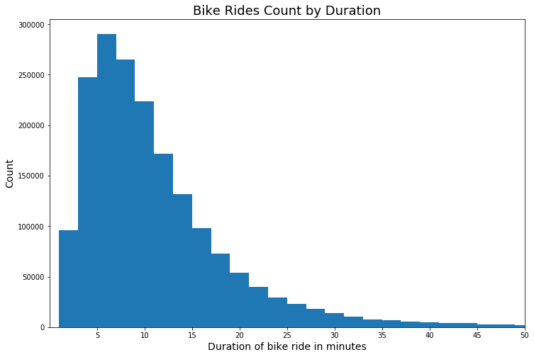

```python
binsize = 2
bins = np.arange(1, df['duration_minutes'].max()+binsize, binsize)
plt.figure(figsize=[12, 8])
plt.hist(data = df, x = 'duration_minutes', bins = bins)
plt.xlabel('Duration of bike ride in minutes',fontsize=14)
plt.ylabel('Count',fontsize=14)
plt.title('Bike Rides Count by Duration',fontsize=18)
plt.xlim(0,50)
plt.xticks([5,10,15,20,25,30,35,40,45,50])
plt.show()
```

### Rides by Subscribers Vs Customers

**Determine who are the main users of the service:**

- **Who uses the service more frequently - Subscribers or Customers?**
- **What is the proportion of the number of Subscribers and Customers?**

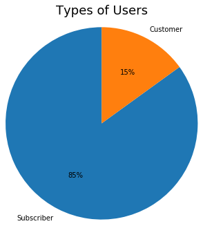

```python
plt.pie(df['user_type'].value_counts(), labels = df['user_type'].value_counts().index,startangle = 90,radius =1.6,autopct='%1.0f%%');
plt.title('Types of Users',fontsize=18, y=1.2);
```

### Rides by Age Group of Users

**Find out the age group of people who use the service:**

- **What is the age group of the users?**
- **Is the service more popular among a particular age group?**

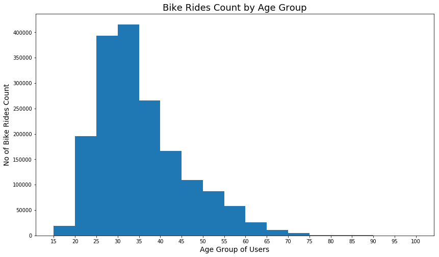

```python
binsize = 5
bins = np.arange(15, 105, binsize)
plt.figure(figsize=[14, 8])
plt.hist(data = df, x = 'age', bins = bins)
plt.xticks([15,20,25,30,35,40,45,50,55,60,65,70,75,80,85,90,95,100])
plt.ylabel('No of Bike Rides Count',fontsize=14)
plt.xlabel('Age Group of Users',fontsize=14)
plt.title('Bike Rides Count by Age Group',fontsize=18)
plt.show()
```

### Rides by Duration and Customer Type

**Investigate differences in behavior between Subscribers and Customers with respect to their usage durations:**

- **Who takes longer rides - Subscribers or Customers?**
- **What is the median trip duration for Subscribers and for Customers?**

```
(0.0, 70.0)
```

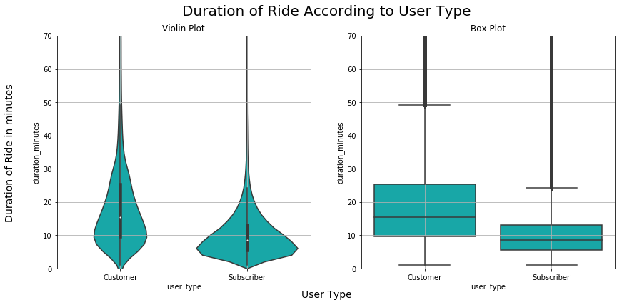

```python
df_duration = df[df['duration_minutes'] < 200] # exclude outliers in the dataset with duration >200 minutes
base_color = sb.color_palette()[0]
fig = plt.figure(figsize = [14, 6])
fig.suptitle("Duration of Ride According to User Type",size = 20)
fig.text(0.5, 0.04, 'User Type', ha='center', va='center',size = 14)
fig.text(0.06, 0.5, 'Duration of Ride in minutes', ha='center', va='center', rotation='vertical',size = 14)

# left plot: violin plot
plt.subplot(1, 2, 1);
ax1 = sb.violinplot(data = df_duration, x = 'user_type', y = 'duration_minutes', color = "c");
ax1.title.set_text('Violin Plot')
plt.grid(True);
plt.ylim(0,70);

# right plot: box plot
plt.subplot(1, 2, 2);
ax2 = sb.boxplot(data = df_duration, x = 'user_type', y = 'duration_minutes', color = "c");
ax2.title.set_text('Box Plot')
plt.grid(True);
plt.ylim(ax1.get_ylim()) # set y-axis limits to be same as left plot;
```

### Rides by Day of Week and Customer Type

**Explore usage trends during the week:**

- **How does the Subscriber usage vary over the week? Are there any noticeable differences between weekdays and weekends use?**
- **How does the Customer usage vary over the week? Are there any noticeable differences between weekdays and weekends use?**

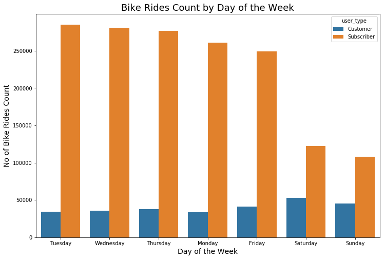

```python
dayofweek_order = df['dayofweek'].value_counts().index
sb.countplot(data = df, x = 'dayofweek', hue = 'user_type',order = dayofweek_order)
plt.ylabel('No of Bike Rides Count',fontsize=14)
plt.xlabel('Day of the Week',fontsize=14)
plt.title('Bike Rides Count by Day of the Week',fontsize=18)
plt.gcf().set_size_inches(12,8);
```

### Rides by Hour of the Day and Customer Type

**Analyse how the service is utilised throughout the day:**

- **How does the usage vary over the 24 hours of the day?**
- **Are there any fluctuations or peak times of usage?**

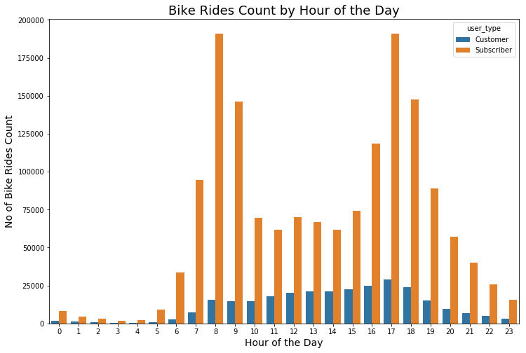

```python
sb.countplot(data = df, x = 'hour_of_day', hue = 'user_type')
plt.ylabel('No of Bike Rides Count',fontsize=14)
plt.xlabel('Hour of the Day',fontsize=14)
plt.title('Bike Rides Count by Hour of the Day',fontsize=18)
plt.gcf().set_size_inches(12,8);
```

### Rides by Month and Customer Type

**Determine any Seasonal Impact on the use:**

- **Does usage remain uniform throughout the year?**
- **Are there any particular months when usage increases or decreases?**

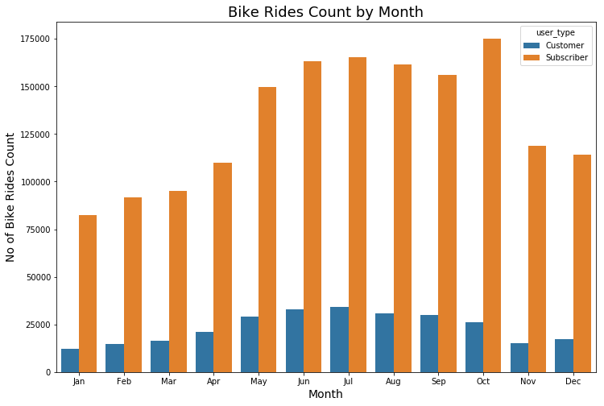

```python
sb.countplot(data = df, x = 'month', hue = 'user_type')
plt.ylabel('No of Bike Rides Count',fontsize=14)
plt.xlabel('Month',fontsize=14)
plt.title('Bike Rides Count by Month',fontsize=18)
plt.gcf().set_size_inches(12,8);
```

### Duration of the Trip in minutes according to User Type and Day of the week.

**Determine behavior variation among Subscribers and Customers with respect to Duration of Trip and Day of the week:**

- **Is there any noticeable difference between median duration of trips undertaken by Subscribers and Customers?**
- **If there is a difference, then does this vary during the week?**

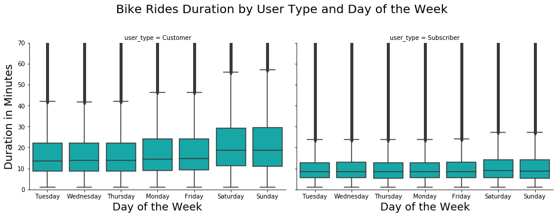

```python
df_duration = df[df['duration_minutes'] < 200]
dayofweek_order = df['dayofweek'].value_counts().index
g = sb.FacetGrid(data = df_duration, col = 'user_type', height = 5,aspect=1.3,margin_titles=False)
plt.ylim(0,70)
g.map(sb.boxplot, 'dayofweek', 'duration_minutes', order = dayofweek_order,color="c");
g.set_xlabels('Day of the Week', size=18)
g.set_ylabels('Duration in Minutes', size=18)
plt.subplots_adjust(top=0.8)
g.fig.suptitle("Bike Rides Duration by User Type and Day of the Week",size=20)
```

## Key Findings and Insights.

- Bike ride duration has a long-tailed distribution and is right-skewed, with a peak between 5-8 minutes.
- Most users (approximately 85%) are subscribers, and only 15% approximately are customers.
- Subscribers, on an average,take shorter duration rides compared to customers.
- The vast majority of users on weekdays are subscribers, whereas on weekdays the number of subscribers decreases. The number of customers are more on weekends compared to weekdays.
- For subscribers, the peak times 8 am and 5 pm, with a much smaller peak at around noon. For customers, there is an increasing trend as the day progresses, but the difference is less pronounced and maximum rides occur between 4pm-6pm (16-18 hours).
- Bike ride count by month shows increased usage during the summer months between May and October, with a decrease in use during the other months for both subscribers and customers.